# 4-6. Anàlisi i resultats

Pol Major Munich

Tipologia i cicle de vida de les dades · Pràctica 2

2018-1 · Màster universitari en Ciència de dades (Data science)

Estudis de Informàtica, Multimèdia i Telecomunicació

# 4-6. Anàlisi i resultats:

· Per aquests apartats s'utilitzaran els fitxers generats als apartats 1-3. S'anomenen 'cleaned_train.csv' i 'cleaned_test.csv'.

```python
import seaborn as sns
import pandas as pd
from matplotlib import pyplot as plt

import numpy as np
import plotly.plotly as py
import plotly.graph_objs as go

from plotly.offline import init_notebook_mode, iplot
init_notebook_mode()


train = pd.read_csv("cleaned_train.csv")
test = pd.read_csv("cleaned_test.csv")

#Es guarda la Id per generar el fitxer 'submit'
test_id = test["PassengerId"]
```

**4. Anàlisi dels resultats**

**4.1 Selecció dels grups a analitzar i comparar** - Aplicació del Gradient Boosting

```python
from sklearn.ensemble import GradientBoostingClassifier
from sklearn import preprocessing

le = preprocessing.LabelEncoder()

y = train["Survived"]
X =train.drop(["Survived","Name","Age","Fare"], axis=1)

X["Title"]= le.fit_transform(X["Title"])
X["Embarked"]= le.fit_transform(X["Embarked"])
X["Sex"]= le.fit_transform(X["Sex"])
X["L_Age"]= le.fit_transform(X["L_Age"])
X["L_Fare"]= le.fit_transform(X["L_Fare"])

X_test = test.drop(["PassengerId","Name","Age","Fare"], axis=1)
X_test["Title"]= le.fit_transform(X_test["Title"])
X_test["Embarked"]= le.fit_transform(X_test["Embarked"])
X_test["Sex"]= le.fit_transform(X_test["Sex"])
X_test["L_Age"]= le.fit_transform(X_test["L_Age"])
X_test["L_Fare"]= le.fit_transform(X_test["L_Fare"])

clf = GradientBoostingClassifier(random_state=0)
clf = clf.fit(X,y)
predict = clf.predict(X_test)

first_submit = pd.DataFrame(test_id.tolist(), columns=["PassengerId"])
first_submit["Survived"] = predict.tolist()
#first_submit.to_csv("first_submit.csv", index=False)
```

**Al aplicar el resultat a Kaggle, s'ha obtingut una precisió del 0.79425.**

[figure not shown]

**4.2 i 4.3 Comprovar la normalització i la variança i test estadístics.**

· Comprovació de la normalitat per les variables contínues. Test basat en D’Agostino i Pearson’s per distribucions normals. La hipòtesi nul·la és que les distribucions són normals.

```
Age  amb p-value 1.7919688803464317e-06
Fare  amb p-value 2.1889771704168276e-92

En tots els casos el p-valor < 0.05, es rebutja la hipòtesis. Sembla que cap segueix una distribució normal, tot i que 'Age' s'hi acosta més.
```

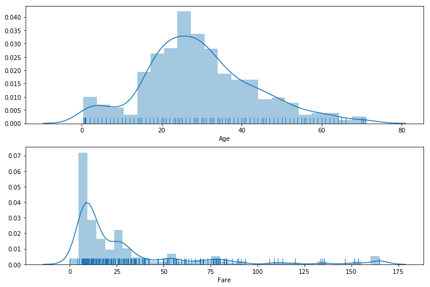

```python
#Scipy servirà per aplicar els diferents test estadístics
import scipy.stats as st

data = pd.read_csv("cleaned_train.csv")

#Les úniques variables numèriques per les que val la pena mirar són 'Age' i 'Fare': (la resta són més aviat categòriques)
to_test = data[["Age","Fare"]]
fig, ax = plt.subplots(len(to_test.columns), figsize=(12,8))
i=0

for a in to_test:
    result = st.normaltest(to_test[a])
    print(a," amb p-value",result[1])
    sns.distplot(to_test[a], ax=ax[i], rug=True)
    i+=1

print("\nEn tots els casos el p-valor < 0.05, es rebutja la hipòtesis. Sembla que cap segueix una distribució normal, tot i que 'Age' s'hi acosta més.")
```

· Homogeneitat de la variança aplicant el test de Fligner-Killeen a les variables 'Age' i 'Fare' agrupades per 'Survived'.

```python
to_test=data[["Survived","Age","Fare"]].groupby("Survived")
g0 = to_test.get_group(0)
g1 = to_test.get_group(1)

for a in g0[["Age","Fare"]]:
    result = st.fligner(g0[a],g1[a])
    print("Homogeneitat de la variança de:",a," amb p-value",result[1])

print(to_test.var())
```

```
Homogeneitat de la variança de: Age  amb p-value 0.10789981265332685
Homogeneitat de la variança de: Fare  amb p-value 2.466824475528314e-21
                 Age         Fare
Survived
0         180.436377   688.002855
1         206.581909  1898.580840
```

**Es rebutja només la homogeneitat de 'Fare', cosa que confirma el fet que 'Fare' és un factor clau en la supervivència ('Survived').**

Amb tot, s'ha decidit discretitzar les variables 'Age' i 'Fare' en 4 parts, segons els quartils, en l'apartat 3 anterior.

**4.3 i 5 - Correlacions i gràfics/taules**

*Com que les dades són majoritàriament categòriques, el test principal que s'utilitzarà serà la correlació de les variables i així poder-les comparar. L'objectiu principal és comparar amb 'Survived', però també es faran altres comparacions.*

· A continuació s'ha dissenyat una funció que mostra **la correlació** entre un conjunt d'atributs i unes variables en concret.

· Per aconseguir-ho, s'utilitza 'Pandas.get_dummies' per relacionar totes les combinacions possibles.

```python
import numpy as np

def correlations(atributs, bys):
    #Prepare the data
    cleaned = pd.read_csv("cleaned_train.csv")
    cleaned[["SibSp","Parch","Pclass","Survived"]] = cleaned[["SibSp","Parch","Pclass","Survived"]].astype(str)

    #Get dummies and set 'by' correlation
    at = list(atributs) + [by for by in bys]
    dummies = pd.get_dummies(cleaned[at])
    total_len = len(dummies.columns)

    #Correlation matrix
    correlations = dummies.corr()

    #Prepare to plot
    data = []
    updatemenus = []
    buttons = []
    colors = ['rgb(255,202,225)','rgb(0,202,225)','rgb(0,100,225)','rgb(100,202,25)','rgb(200,202,0)']
    i=0
    l = len(pd.get_dummies(cleaned[bys]).columns)

    for by in bys:
        for b in pd.get_dummies(cleaned[by]):
            v=False
            visible=[]
            for x in range(l):
                visible.append(False)
            visible[i]=True
            st = by+"_"+b
            corr_s = correlations[st]
            corr_s = corr_s.sort_values(ascending=True)
            x = corr_s[1:-1]
            y = corr_s.index[1:-1]
            if i==0:
                v = True
                init_title = st
            data.append(go.Bar( x=x,
                                y=y,
                                name=st,
                                text=round(x,2),
                                textposition = 'auto',
                                orientation = 'h',
                                visible=v,
                                marker=dict(
                                    color=colors[np.random.randint(5)],

                                ),
                                opacity=1
                            ))
            buttons.append(dict(label = st,
                                 method = 'update',
                                 args = [{'visible': visible},
                                {'title': 'Correlations by '+st}]))
            i+=1

        updatemenus = list([
            dict(active=0,
                 x=0, y=1.1875,
                 buttons=buttons)])

        layout = go.Layout(
            title='Correlations by '+init_title,
            yaxis={'title':'Dummies', 'fixedrange': True} ,  xaxis={'title':'Correlations', 'fixedrange':True} ,
            autosize=True,
            height=800,
            updatemenus=updatemenus
            )

    fig = go.Figure(data=data, layout=layout)
    iplot(fig, filename='grouped-bar')

correlations(["L_Fare","L_Age"], ["Sex"])
```

[interactive chart not shown]

```python
#Comprovació numèrica del graf anterior:
print("Es poden comprovar les correlacions a partir de calcular els percentatges corresponents a cada atribut.\nPer exemple, hi hauria d'haver més percentatge de dones joves que d'homes joves (<21). A més, els homes haurien de tenir més percentatge de tarifes baixes (<14):\n")
female = data.groupby("Sex").get_group("female")["Age"]
male = data.groupby("Sex").get_group("male")["Age"]

print("Un",female[female<=21].count()*100/len(female),"% de les dones eren més petites de 21 anys.")
print("Un",male[male<=21].count()*100/len(male),"% dels homes eren més petits de 21 anys.")

female = data.groupby("Sex").get_group("female")["Fare"]
male = data.groupby("Sex").get_group("male")["Fare"]

print("\nUn",female[female<=14].count()*100/len(female),"% de les dones tenia una tarifa de menys de 14.")
print("Un",male[male<=14].count()*100/len(male),"% dels homes tenia una tarifa de menys de 14.")
```

```
Es poden comprovar les correlacions a partir de calcular els percentatges corresponents a cada atribut.
Per exemple, hi hauria d'haver més percentatge de dones joves que d'homes joves (<21). A més, els homes haurien de tenir més percentatge de tarifes baixes (<14):

Un 34.07643312101911 % de les dones eren més petites de 21 anys.
Un 23.91681109185442 % dels homes eren més petits de 21 anys.

Un 33.12101910828026 % de les dones tenia una tarifa de menys de 14.
Un 57.712305025996535 % dels homes tenia una tarifa de menys de 14.
```

*Representació dels resultats - Correlacions de supervivència*

```python
correlations(["Pclass","Sex","Embarked","SibSp","Parch","L_Fare","L_Age","Title"], ["Survived"])
```

[interactive chart not shown]

*Qui va sobreviure?* · Amb un cop d'ull a les gràfiques es veu que les següents característiques ajudaven a la supervivència:

1. Ser de classe 1 o 2.
2. Ser dona.
3. Haver embarcat al port 'C'
4. Tenir una tarifa cara (Fare (31,165]).
5. Ser jove (menys de 21 anys).
6. Tenir 1 o 2 germans (SibSp).
7. Tenir 1 o 2 parents (Parch).

· Altres preguntes que sorgeixen són: "Com es relaciona l'embarcament i la resta d'atributs? Per què embarcar per un lloc o altre ha de tenir influència en la supervivència?"

```python
correlations(["Pclass","Sex","Survived","SibSp","Parch","L_Fare","L_Age","Title"],["Embarked"])
```

[interactive chart not shown]

**D'aquí se'n treuen reflexions importants:** l'embarcament va molt lligat a la tarifa, que al seu torn va lligat a la supervivència. A més, les dones tenien tarifes més altes i embarcaven més als ports 'C' i 'Q' i sabem que van sobreviure més dones. D'alguna manera, totes aquestes variables van lligades. És tracta de relacions de causalitat. Possiblement la gent de classe alta, de tarifa alta, i moltes de les dones embarcaven per 'C' o 'Q'. Potser a l'hora del rescat, són precisament aquestes persones les que van prioritzar en el salvament, d'aquí a que aquests embarcament mostrin alta probabilitat de supervivència.

**Per acabar, el següent gràfic interactiu permet aprofundir en totes les correlacions dels atributs:**

```python
correlations([],["Title","Survived","Pclass","Sex","Embarked","SibSp","Parch","L_Fare","L_Age"])
```

[interactive chart not shown]

**Es pot inferior la classe d'algú (sense saber si va sobreviure o no)? Amb quina precisió?** - Abre de decisió

```python
from sklearn.tree import DecisionTreeClassifier
from sklearn.metrics import accuracy_score

#Es preparen les dades
trax = X[["Sex","SibSp","Parch","Embarked","L_Age","L_Fare","Title"]]
tray = X[["Pclass"]]

tesx = X_test[["Sex","SibSp","Parch","Embarked","L_Age","L_Fare","Title"]]
tesy = X_test[["Pclass"]]

#Per fondària de l'arbre entre 2 i 15, els resultats són:
for x in range(2,15):
    regr = DecisionTreeClassifier(random_state=0, max_depth=x)
    regr.fit(trax, tray)
    result = regr.predict(tesx)
    acc = accuracy_score(tesy,result)
    print("El resultat per depth=",x,"és: ",acc*100,"%.")

print("\nEl millor resultat és del 78% per un arbre de fondària 9.")
print("Com s'ha vist els atributs estan altament relacionats i és viable fer-ne prediccions.")
```

```
El resultat per depth= 2 és:  63.63636363636363 %.
El resultat per depth= 3 és:  68.42105263157895 %.
El resultat per depth= 4 és:  72.00956937799043 %.
El resultat per depth= 5 és:  72.00956937799043 %.
El resultat per depth= 6 és:  73.20574162679426 %.
El resultat per depth= 7 és:  75.35885167464114 %.
El resultat per depth= 8 és:  74.64114832535886 %.
El resultat per depth= 9 és:  77.99043062200957 %.
El resultat per depth= 10 és:  77.27272727272727 %.
El resultat per depth= 11 és:  77.51196172248804 %.
El resultat per depth= 12 és:  77.27272727272727 %.
El resultat per depth= 13 és:  77.75119617224881 %.
El resultat per depth= 14 és:  77.75119617224881 %.

El millor resultat és del 78% per un arbre de fondària 9.
Com s'ha vist els atributs estan altament relacionats i és viable fer-ne prediccions.
```

**Es pot inferior l'edat algú (sense saber si va sobreviure o no)? Amb quina precisió?** - Arbrés de Regressió

```python
from sklearn.tree import DecisionTreeRegressor

#Es preparen les dades
train_age = train["Age"]
test_age = test["Age"]

dtr = DecisionTreeRegressor().fit(X.drop("L_Age",axis=1),train_age)
p_age = dtr.predict(X_test.drop("L_Age",axis=1))
```

```python
#Per calcular la precisió no n'hi ha prou amb comparar els valors. Es provarà amb marges d'error de +-5% incrementanls:
l=[]
r=[]
print("Total d'exemples: ",len(test_age))
for x in range(0,23):
    count=0
    for real,predicted in zip(test_age,p_age):
        if ((predicted+(0.025*x*max(test_age))>= real)) and ((predicted-(0.025*x*max(test_age))<= real)):
            count+=1
    r.append(x)
    l.append(round(count*100/len(test_age),2))

predict_df = pd.DataFrame(l, columns=["Prediccions Correctes en %"])
predict_df["Marge d'error permès en %"] = [(x*2.5) for x in r]
print(predict_df)

trace_predict = go.Scatter(x=predict_df["Marge d'error permès en %"],
                       y=predict_df["Prediccions Correctes en %"],
                       mode = 'lines+markers',
                       line=dict(color='#33CFA5'))

layout = go.Layout(
    title='Prediccions correctes respecte el marge d\'error',
    yaxis={'title':'Prediccions Correcte en %'} ,  xaxis={'title':'Marge d\'error permès en %'}
)

fig = dict(data=[trace_predict], layout=layout)
iplot(fig, filename='Predict_Scatter')
```

```
Total d'exemples:  418
    Prediccions Correctes en %  Marge d'error permès en %
0                         3.83                        0.0
1                        15.31                        2.5
2                        30.86                        5.0
3                        44.26                        7.5
4                        53.59                       10.0
5                        63.64                       12.5
6                        71.29                       15.0
7                        76.79                       17.5
8                        82.54                       20.0
9                        85.65                       22.5
10                       88.52                       25.0
11                       92.11                       27.5
12                       93.06                       30.0
13                       93.78                       32.5
14                       94.26                       35.0
15                       95.22                       37.5
16                       95.69                       40.0
17                       96.41                       42.5
18                       97.37                       45.0
19                       97.85                       47.5
20                       99.04                       50.0
21                       99.76                       52.5
22                      100.00                       55.0
```

[interactive chart not shown]

**Interpretació de la predicció d'edat**

·Soprenentment, es pot predir l'edat amb un marge d'error del 20% en més del 80% dels casos.

·El 100% de precisió s'obté amb un 55% marge d'error.

·Mirant la corba, el punt òptim entre millora i precisió seria en el 27.5% de marge d'error, on es predeix ja correctament el 92% dels casos.

**6. Resolució del problema**

· Sí, els resultats permeten resoldre els problemes. Com s'ha vist anteriorment, s'han respost les preguntes:

1. 'Qui va sobreviure?'
2. 'Com es relaciona l'embarcament i la resta d'atributs?'
3. 'Per què embarcar per un lloc o altre ha de tenir influència en la supervivència?'

·A més, s'ha predit amb força èxit tant la classe d'una persona com la seva edat, **sense** tenir en compte si havia sobreviscut o no.

·S'ha demostrat, amb tot, una alta correlació entre diverses variables.

·Per acabar de consolidar els resultats, s'ha aplicat la solució a Kaggle amb un resultat força bo: 0.79425.